# Practical Machine Learning - Week 4 - Course Project

Chris Payne

10/02/2021

## Introduction

These models are then used to predict the classification of exercise in the test set (the results of which are submitted as part of the overall project assessment)

## Retrieve and Prepare Data

The first step of any data analysis is to obtain your data perform any required transformations and complete an initial exploratory analysis.

```r
# define destination and source files for test and training data sets
trainfile <- "pml-training.csv"
testfile <- "pml-testing.csv"
trainfileURL <-
 "https://d396qusza40orc.cloudfront.net/predmachlearn/pml-training.csv"
testfileURL <- "https://d396qusza40orc.cloudfront.net/predmachlearn/pml-testing.csv"

# only download if the testing and training data set don't exist
if (!file.exists(trainfile)) {
    download.file(trainfileURL ,trainfile,method="auto")
 }
if (!file.exists(testfile)) {
    download.file(testfileURL ,testfile,method="auto")
 }

# load the testing and training data set
train = read.csv("pml-training.csv")
test = read.csv("pml-testing.csv")

# convert the classe variable in the training set into a factor variable
train$classe <- as.factor(train$classe)
```

So, we now have train and test data sets. Using the dim function we can ascertain that the training data set has 19622 observations of 160 variables, with the testing set containing 20 observations of 160 variables. The only significant difference between the two data sets is that the training data set has a ‘classe’ variable (the classification of how the exercise was completed) which is now a factor variable (A,B,C,D,E) while the test data set has a problem_id variable (which is used when completing the quiz component of this course).

```r
names(train)
```

```
##   [1] "X"                        "user_name"
##   [3] "raw_timestamp_part_1"     "raw_timestamp_part_2"
##   [5] "cvtd_timestamp"           "new_window"
##   [7] "num_window"               "roll_belt"
##   [9] "pitch_belt"               "yaw_belt"
##  [11] "total_accel_belt"         "kurtosis_roll_belt"
##  [13] "kurtosis_picth_belt"      "kurtosis_yaw_belt"
##  [15] "skewness_roll_belt"       "skewness_roll_belt.1"
##  [17] "skewness_yaw_belt"        "max_roll_belt"
##  [19] "max_picth_belt"           "max_yaw_belt"
##  [21] "min_roll_belt"            "min_pitch_belt"
##  [23] "min_yaw_belt"             "amplitude_roll_belt"
##  [25] "amplitude_pitch_belt"     "amplitude_yaw_belt"
##  [27] "var_total_accel_belt"     "avg_roll_belt"
##  [29] "stddev_roll_belt"         "var_roll_belt"
```

[output cut: 65 more lines]

## Create Predictive Models

Running the r command str (not included as it adds little value to the analysis) indicates that there are a large number of variables that either contain NAs or are non-numeric. There are also variables covering user_name, timestamps, windows and the observation number. So, lets prepare our training data so we can exclude them in future work and then display the remaining variable names.

```r
trainNA <- train[ , colSums(is.na(train)) == 0]
nums <- unlist(lapply(trainNA, is.numeric))
names(trainNA[,nums])
```

```
##  [1] "X"                    "raw_timestamp_part_1" "raw_timestamp_part_2"
##  [4] "num_window"           "roll_belt"            "pitch_belt"
##  [7] "yaw_belt"             "total_accel_belt"     "gyros_belt_x"
## [10] "gyros_belt_y"         "gyros_belt_z"         "accel_belt_x"
## [13] "accel_belt_y"         "accel_belt_z"         "magnet_belt_x"
## [16] "magnet_belt_y"        "magnet_belt_z"        "roll_arm"
## [19] "pitch_arm"            "yaw_arm"              "total_accel_arm"
## [22] "gyros_arm_x"          "gyros_arm_y"          "gyros_arm_z"
## [25] "accel_arm_x"          "accel_arm_y"          "accel_arm_z"
## [28] "magnet_arm_x"         "magnet_arm_y"         "magnet_arm_z"
## [31] "roll_dumbbell"        "pitch_dumbbell"       "yaw_dumbbell"
## [34] "total_accel_dumbbell" "gyros_dumbbell_x"     "gyros_dumbbell_y"
## [37] "gyros_dumbbell_z"     "accel_dumbbell_x"     "accel_dumbbell_y"
## [40] "accel_dumbbell_z"     "magnet_dumbbell_x"    "magnet_dumbbell_y"
## [43] "magnet_dumbbell_z"    "roll_forearm"         "pitch_forearm"
## [46] "yaw_forearm"          "total_accel_forearm"  "gyros_forearm_x"
## [49] "gyros_forearm_y"      "gyros_forearm_z"      "accel_forearm_x"
## [52] "accel_forearm_y"      "accel_forearm_z"      "magnet_forearm_x"
## [55] "magnet_forearm_y"     "magnet_forearm_z"
```

Lets identify the degree of correlation between our predictors and only consider the 8 least correlated for our classification models (this may lead to an appropriate selection of predictors) and then display these predictors in a pairs plot to verify no visible correlations.

```r
library(caret)
library(mlbench)
```

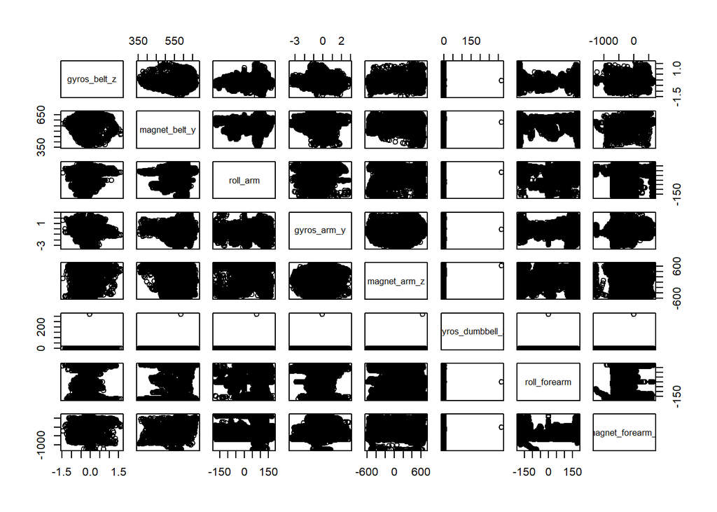

```r
library(ggplot2)
library(kernlab)
# Remove columns containing NA
trainNA <- train[ , colSums(is.na(train)) == 0]
# Identify variables that are numeric
nums <- unlist(lapply(trainNA, is.numeric))
# variables 1 to 7 are: username, timestamp etc so remove from num vector
nums[1:7] <- FALSE

# Create a correlation Matrix and find highly correlated variables
numericVariables <- trainNA[,nums]
correlationMatrix <- cor(numericVariables)
highlyCorrelated <- findCorrelation(correlationMatrix, cutoff=0.2)
predictorVariables <- numericVariables[,-highlyCorrelated]

# Display a pairs plot of our select predictors
pairs(trainNA[,names(predictorVariables)])
```

The variables with a correlation of 0.2 or less were identified as: *gyros_belt_z*  
magnet_belt_y  
*roll_arm gyros_arm_y*  
magnet_arm_z  
*gyros_dumbbell_z* roll_forearm  
*magnet_forearm_x

We can now build a number of classification models (using the caret package) using a variety of different models, using classe as the outcome. For this project we will use: * Random Forest (RF)  
* Learning Vector Quantization (LVQ)  
* Gradient Boosting Model (GBM)  
* Support Vector Machine  
Next we use these models to predict the outcome of our test set (we will implement cross-validation by setting the trControl attribute in the caret package train function: dividing the training dataset randomly into 10 parts and then using each of 10 parts as testing dataset for the model trained on other 9).

Finally, we will diaply a summary of the results and plot them in a boxplot.

```r
# Correct answers (trial and error)
correct <- c("B","A","B","A","A","E","D","B","A","A","B","C","B","A","E","E","A","B","B","B")

# Specify train control parameters
control <- trainControl(method="repeatedcv", number=10, repeats=3)

# Create a RF predictor and predictions using our selected predictorVariables
set.seed(2021)
rf_classifierPV <- train(classe~gyros_belt_z+magnet_belt_y+roll_arm+gyros_arm_y+magnet_arm_z+gyros_dumbbell_z+roll_forearm+magnet_forearm_x, data=trainNA, method="rf", trControl=control)

rf_predictPV <- predict(rf_classifierPV,test)

# Create a LVQ predictor and predictions using our selected predictorVariables
set.seed(2021)
lvq_classifierPV <- train(classe~gyros_belt_z+magnet_belt_y+roll_arm+gyros_arm_y+magnet_arm_z+gyros_dumbbell_z+roll_forearm+magnet_forearm_x, data=trainNA, method="lvq", trControl=control)

lvq_predictPV <- predict(lvq_classifierPV,test)

# Create a GBM predictor and predictions using our selected predictorVariables
set.seed(2021)
gbm_classifierPV <- train(classe~gyros_belt_z+magnet_belt_y+roll_arm+gyros_arm_y+magnet_arm_z+gyros_dumbbell_z+roll_forearm+magnet_forearm_x, data=trainNA, method="gbm", trControl=control, verbose=FALSE)

gbm_predictPV <- predict(gbm_classifierPV,test)

# Create a SVM predictor and predictions using our selected predictorVariables
set.seed(2021)
svm_classifierPV <- train(classe~gyros_belt_z+magnet_belt_y+roll_arm+gyros_arm_y+magnet_arm_z+gyros_dumbbell_z+roll_forearm+magnet_forearm_x, data=trainNA, method="svmRadial", trControl=control)

svm_predictPV <- predict(svm_classifierPV,test)

results <- resamples(list(RF=rf_classifierPV,LVQ=lvq_classifierPV,GBM=gbm_classifierPV,SVM=svm_classifierPV))
# summarize the distributions
summary(results)
```

```
##
## Call:
## summary.resamples(object = results)
##
## Models: RF, LVQ, GBM, SVM
## Number of resamples: 30
##
## Accuracy
##          Min.   1st Qu.    Median      Mean   3rd Qu.      Max. NA's
## RF  0.9444727 0.9481462 0.9508286 0.9513809 0.9550204 0.9587576    0
## LVQ 0.3083588 0.3403822 0.3632194 0.3571335 0.3698750 0.3998981    0
## GBM 0.7526772 0.7581202 0.7668191 0.7659256 0.7709369 0.7824758    0
## SVM 0.7264391 0.7425190 0.7480897 0.7498223 0.7588885 0.7776645    0
##
## Kappa
##          Min.   1st Qu.    Median      Mean   3rd Qu.      Max. NA's
## RF  0.9298441 0.9344427 0.9378274 0.9385295 0.9431325 0.9478649    0
## LVQ 0.1238848 0.1609635 0.1873242 0.1842886 0.2037446 0.2347161    0
## GBM 0.6867453 0.6937552 0.7049863 0.7038751 0.7104610 0.7249628    0
## SVM 0.6534676 0.6744422 0.6818154 0.6836222 0.6950623 0.7187023    0
```

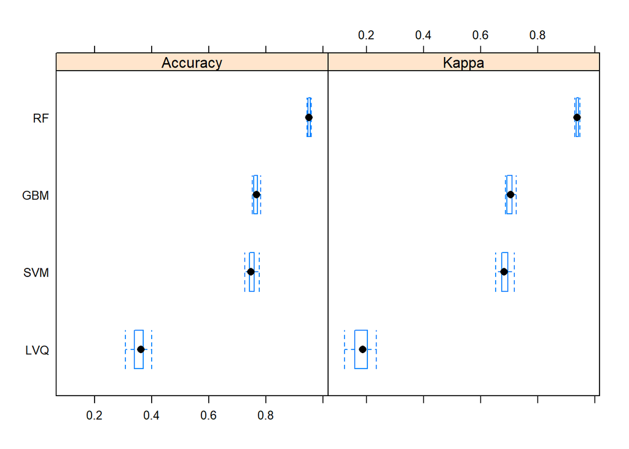

```r
# boxplots of results
bwplot(results)
```

```r
confusionMatrix(as.factor(correct),rf_predictPV)
```

```
## Confusion Matrix and Statistics
##
##           Reference
## Prediction A B C D E
##          A 7 0 0 0 0
##          B 0 6 1 1 0
##          C 0 0 1 0 0
##          D 0 0 0 1 0
##          E 0 0 0 0 3
##
## Overall Statistics
##
##                Accuracy : 0.9
##                  95% CI : (0.683, 0.9877)
##     No Information Rate : 0.35
##     P-Value [Acc > NIR] : 5.277e-07
##
##                   Kappa : 0.8621
##
##  Mcnemar's Test P-Value : NA
##
## Statistics by Class:
##
##                      Class: A Class: B Class: C Class: D Class: E
## Sensitivity              1.00   1.0000   0.5000   0.5000     1.00
## Specificity              1.00   0.8571   1.0000   1.0000     1.00
## Pos Pred Value           1.00   0.7500   1.0000   1.0000     1.00
## Neg Pred Value           1.00   1.0000   0.9474   0.9474     1.00
## Prevalence               0.35   0.3000   0.1000   0.1000     0.15
## Detection Rate           0.35   0.3000   0.0500   0.0500     0.15
## Detection Prevalence     0.35   0.4000   0.0500   0.0500     0.15
## Balanced Accuracy        1.00   0.9286   0.7500   0.7500     1.00
```